# Prior distributions and uncertainty

DSCI 632: Statistics for Data Science

Peter Ralph

# Biased coins

## a motivating example

Suppose I have two trick coins:

- one (coin A) comes up heads 75% of the time, and
- the other (coin B) only 25% of the time.

But, I lost one and I don’t know which! So, I flip it **10 times** and get **6 heads**. *Which is it, and how sure are you?*

## Possible answers:

1. Er, probably coin (A)?
2. Well,
   $$\begin{aligned}
   \P\{ \text{6 H in 10 flips} \given \text{coin A} \}
   &= \binom{10}{6} (.75)^6 (.25)^4 \\
   &= 0.146
   \end{aligned}$$
   and
   $$\begin{aligned}
   \P\{ \text{6 H in 10 flips} \given \text{coin B} \}
   &= \binom{10}{6} (.25)^6 (.75)^4 \\
   &= 0.016
   \end{aligned}$$
   … so, probably coin (A)?

For a precise answer…

3. *Before flipping*, each coin seems equally likely. Then

   $$\begin{aligned}
   \P\{ \text{coin A} \given \text{6 H in 10 flips} \}
   &= \frac{
   \frac{1}{2} \times 0.146
   }{
   \frac{1}{2} \times 0.146
   +
   \frac{1}{2} \times 0.016
   } \\
   &= 0.9
   \end{aligned}$$

# Probability

## Bayes’ rule

$$\begin{aligned}
\P\{B \given A\} = \frac{\P\{B\} \P\{A \given B\}}{ \P\{A\} } ,
\end{aligned}$$

where

- $B$: possible model
- $A$: data
- $\P\{B\}$: prior weight on model $B$
- $\P\{A \given B\}$: likelihood of data under $B$
- $\P\{B\} \P\{A \given B\}$: posterior weight on $B$
- $\P\{A\}$: total sum of posterior weights

# Breaking it down with more coins

Suppose instead I had 9 coins, with probabilities 10%, 20%, …, 90%; as before I flipped one 10 times and got 6 heads. For each $\theta$ in $0.1, 0.2, \ldots, 0.8, 0.9,$ find
$$\begin{aligned}
\P\{\text{ coin has prob $\theta$ } \given \text{ 6 H in 10 flips }
\} .
\end{aligned}$$

*Question:* which coin(s) is it, and how sure are we? (And, what does it mean when we say how sure we are?)

## Uniform prior

prior

$\times$

likelihood

$\propto$

posterior

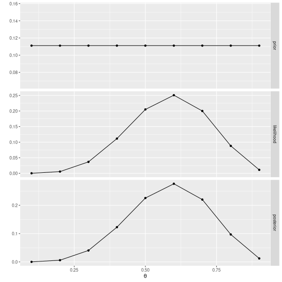

## Weak prior

prior

$\times$

likelihood

$\propto$

posterior

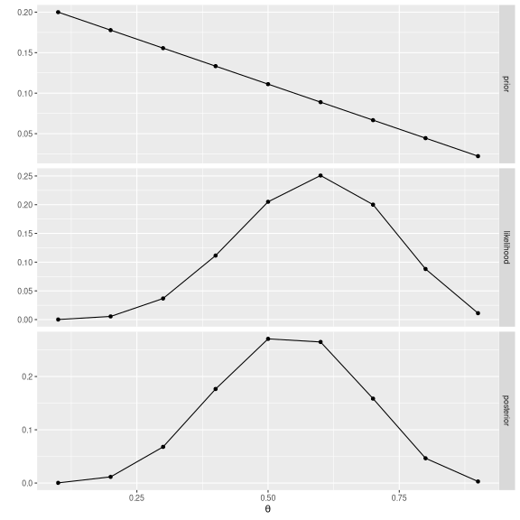

## Strong prior

prior

$\times$

likelihood

$\propto$

posterior

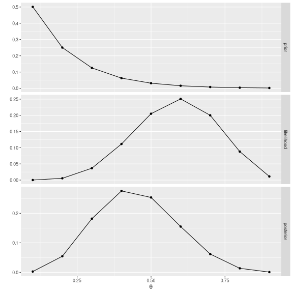

## The likelihood: 6 H in 10 flips

prior

$\times$

likelihood

$\propto$

posterior

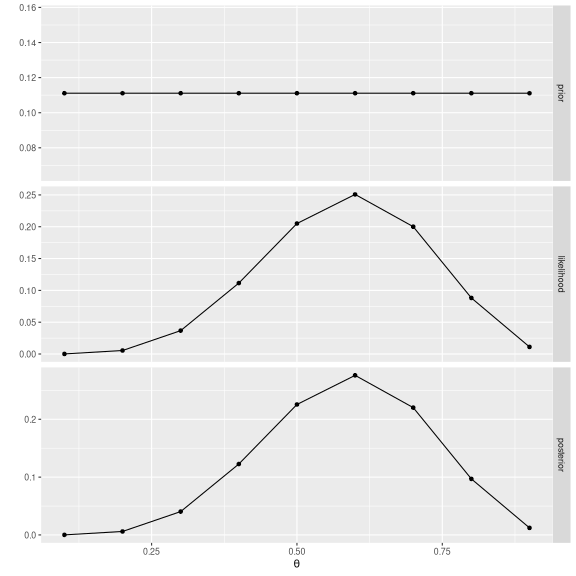

## The likelihood: 30 H in 50 flips

prior

$\times$

likelihood

$\propto$

posterior

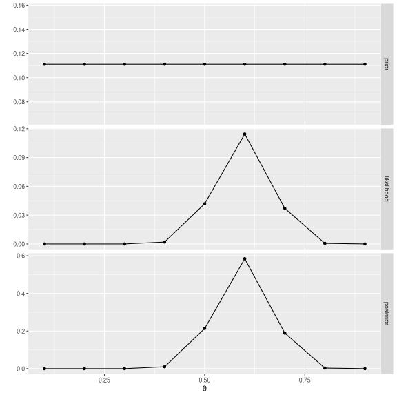

## The likelihood: 60 H in 100 flips

prior

$\times$

likelihood

$\propto$

posterior

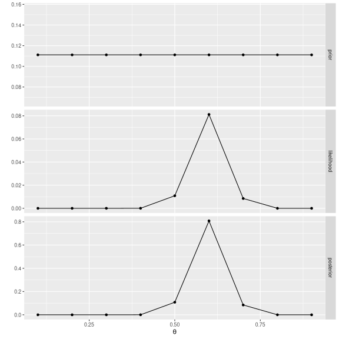

## The likelihood: 6,000 H in 10,000 flips

prior

$\times$

likelihood

$\propto$

posterior

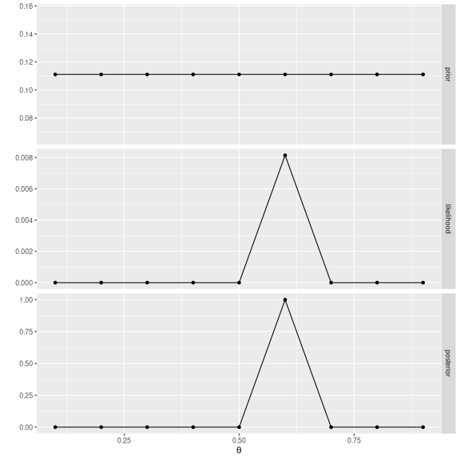

# A question

## What is the right answer to the “coin question”?

Recall: there were nine possible values of $\theta$.

Which coin is it, and how sure are you?

*Possible types of answer:*

1. “best guess”
2. “range of values”
3. “don’t know”

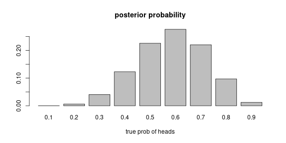

```r
theta <- (1:9)/10
prior <- rep(1/9, 9)
likelihood <- dbinom(6, size=10, prob=theta)
posterior <- prior*likelihood/sum(prior*likelihood)
names(posterior) <- theta
barplot(posterior, xlab='true prob of heads', main='posterior probability')
```

# Unknown coins

## Motivating example

Now suppose we want to estimate the probability of heads for a coin *without* knowing the possible values. (or, a disease incidence, or error rate in an experiment, …)

We flip it $n$ times and get $z$ Heads.

The *likelihood* of this, given the prob-of-heads $\theta$, is:
$$p(z \given \theta) = \binom{n}{z}\theta^z
(1-\theta)^{n-z} .$$

How to weight the possible $\theta$? Need a flexible set of weighting functions, i.e., **prior distributions** on $[0,1]$.

- **Beta** distributions.

What $\alpha$ and $\beta$ would we use for a $\Beta(\alpha, \beta)$ prior if:

- the coin is probably close to fair.
- the disease is probably quite rare.
- no idea whatsoever.

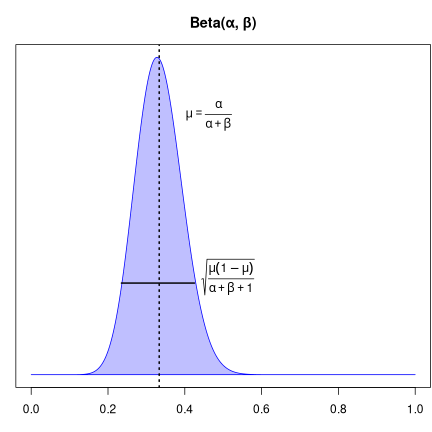

## Beta-Binomial Bayesian analysis

If
$$\begin{aligned}
P &\sim \text{Beta}(a,b) \\
Z &\sim \text{Binom}(n,P) ,
\end{aligned}$$

then “miraculously”,

$$\begin{aligned}
(P \given Z = z) \sim \text{Beta}(a+z, b+n-z) .
\end{aligned}$$

## Discuss:

We flip an odd-looking coin 100 times, and get 65 heads. What is it’s true* probability of heads?

1. What prior to use?
2. Plot the prior and the posterior.
3. Is it reasonable that $\theta = 1/2$?
4. Best guess at $\theta$?
5. How far off are we, probably?

*Tools include:* `rbeta( )`

## IN CLASS

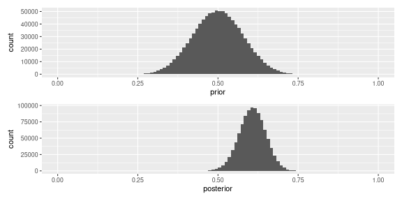

```r
library(patchwork)
n <- 100
z <- 65
prior_a <- 20
prior_b <- 20
post_a <- prior_a + z
post_b <- prior_b + n - z

df <- data.frame(
    prior = rbeta(1000000, prior_a, prior_b),
    posterior = rbeta(1000000, post_a, post_b)
)
p1 <- df |> ggplot(aes(x=prior)) + geom_histogram(bins=100) +
    lims(x=c(0,1))
p2 <- df |> ggplot(aes(x=posterior)) + geom_histogram(bins=100) +
    lims(x=c(0,1))
p1 / p2
```

We’re quite sure the coin is not fair: only 0.5% of the posterior is below 0.5:

```r
# (3) P(<0.5)
pbeta(0.5, post_a, post_b)
```

```
## [1] 0.005339143
```

Our best guess (posterior mode) is about 0.6.

```r
# (3) posterior mode
(post_a - 1) / (post_a + post_b - 2)
```

```
## [1] 0.6086957
```

A 95% credible interval for the probability is from 0.52 to 0.69: we think the true probability is probably between 52% and 69%.

```r
# (4) middle 95%
qbeta(c(0.025, 0.975), post_a, post_b)
```

```
## [1] 0.5252131 0.6861724
```